# Text Analytics (Northwestern University, MLDS 414)

# Introduction to NLTK, Part 2

## Yuri Balasanov, Leonid Nazarov © iLykei 2018-2024

##### Main text: Natural Language Processing with Python, Steven Bird, Ewan Klein & Edward Loper, © Steven Bird, Ewan Klein & Edward Loper 2009, O'Reilly Media, Inc

Import package *nltk*

Download collection of books contained in *nltk* for examples. In the dialogue opened by *nltk.download()* select line *books*.

```python
import nltk
```

# Lexical resources

**Lexicon** or ** lexical resource** in NLP means a collection of words/phrases along with some associated information, such as part-of-speech (**pos**) sense definition, semantics, synonyms, etc.

Lexicon consists of rows called **lexical entries**. A typical structure of lexical entry is:

- **Headword**, also known as **lemma**. This is the reference word
- Part-of-speech or **lexical category**
- Sense definition or **gloss**

Simplest lexicon is just a sorted list of words.

Lexicons contain the most important information for natural language processing: they allow analyzing the meaning of the text as opposed to collecting some summary statistics like frequencies of words, etc.

Some of the most important lexical resources contained in NLTK are reviewed below.

## Wordlist corpora

### Corpus `words`

Corpus called `words` is the `/usr/dict/words` file from Unix. It can be used to find unusual or misspelled words contained in the document.

The following function creates vocabulary of the text, then removes all "standard" words contained in a wordlist leaving only unusual or misspelled words.

Function `s.isalpha()` tests if `s` is non-empty and all characters in `s` are alphabetic.

```python
def unusual_words(text):
    text_vocab=set(w.lower() for w in text if w.isalpha())
    english_vocab=set(w.lower() for w in nltk.corpus.words.words())
    unusual=text_vocab.difference(english_vocab)
    return sorted(unusual)
```

Print all words that are in Blake's poems, but not in corpus `words`

```python
print(unusual_words(nltk.corpus.gutenberg.words('blake-poems.txt')))
```

```
['adona', 'angels', 'answerd', 'answered', 'appals', 'appeared', 'appears', 'arrows', 'babes', 'bags', 'baits', 'bands', 'beadles', 'beams', 'bears', 'beasts', 'became', 'began', 'beguiled', 'beguiles', 'bells', 'bereaved', 'binds', 'birds', 'blasts', 'blights', 'blossoms', 'blushed', 'bodies', 'bon…
```

Some of the words used by William Blake (1757-1827) are not that unusual.

Unusual words list coming from 21-st century chats is more rich:

```python
print(unusual_words(nltk.corpus.nps_chat.words())[:100])
```

```
['aaaaaaaaaaaaaaaaa', 'aaahhhh', 'abortions', 'abou', 'abourted', 'abs', 'ack', 'acros', 'actualy', 'adams', 'adds', 'adduser', 'adjusts', 'adoted', 'adreniline', 'ads', 'adults', 'afe', 'affairs', 'affari', 'affects', 'afk', 'agaibn', 'ages', 'aggravated', 'agurlwithbigguns', 'ahah', 'ahahah', 'aha…
```

### Corpus *stopwords*

This lexicon contains frequent words that usually do not contain a lot of information. Examples are *a*, *the*, *I*, *me*, *you*, etc.

```python
from nltk.corpus import stopwords
print('Eglish:',stopwords.words('english')[:10])
print('Spanish:',stopwords.words('spanish')[:10])
print('Swedish:',stopwords.words('swedish')[:10])
print('Russian:',stopwords.words('russian')[:10])
print('Greek:',stopwords.words('greek')[:10])
```

```
Eglish: ['i', 'me', 'my', 'myself', 'we', 'our', 'ours', 'ourselves', 'you', "you're"]
Spanish: ['de', 'la', 'que', 'el', 'en', 'y', 'a', 'los', 'del', 'se']
Swedish: ['och', 'det', 'att', 'i', 'en', 'jag', 'hon', 'som', 'han', 'på']
Russian: ['и', 'в', 'во', 'не', 'что', 'он', 'на', 'я', 'с', 'со']
Greek: ['αλλα', 'αν', 'αντι', 'απο', 'αυτα', 'αυτεσ', 'αυτη', 'αυτο', 'αυτοι', 'αυτοσ']
```

Create function calculating fraction of words in text that are not on stopwords list. Then check what part of news documents stopwords usually take.

```python
def content_fraction(text):
    stopwords=nltk.corpus.stopwords.words('english')
    content=[w for w in text if w.lower() not in stopwords]
    return len(content)/len(text)
```

```python
print('Not in stop words: ',content_fraction(nltk.corpus.reuters.words()))
```

```
Not in stop words:  0.735240435097661
```

Create a function that solves the following well known word puzzle:

**Create as many as possible words of 4 letters or more from the given letters 'egivrvonl'. Each letter can be used only once per word. Each word must contain letter 'r' and there must be at least one 9-letter word. No plurals ending in "s", no foreign words, no proper names**.

**Results**:

- 21 words: good;
- 32 words: very good;
- 42 words: excellent.

```python
def solve_puzzle(given_letters,obligatory):
    puzzle_letters=nltk.FreqDist(given_letters)
    wordlist=nltk.corpus.words.words()
    return [w for w in wordlist if \
            len(w) >= 4 \
           and obligatory in w \
           and nltk.FreqDist(w) <= puzzle_letters]
```

```python
my_solution=solve_puzzle('egivrvonl','r')
print('Number of words:',len(my_solution))
print('My words:',my_solution)
```

```
Number of words: 92
My words: ['enrol', 'ergon', 'genro', 'girl', 'girn', 'giro', 'giver', 'glor', 'glore', 'glover', 'goer', 'goner', 'gore', 'gorlin', 'govern', 'grein', 'grin', 'groin', 'grove', 'grovel', 'ignore', 'inro', 'involver', 'iron', 'irone', 'levir', 'lienor', 'lier', 'liner', 'linger', 'lire', 'liver', 'l…
```

### Names corpus

Below create a list of names that are both male and female

```python
names=nltk.corpus.names
print(names.fileids())
male_names=names.words('male.txt')
female_names=names.words('female.txt')
print('Number of male names:',len(male_names))
print('Number of female names:',len(female_names))
ambiguous_names=[w for w in male_names if w in female_names]
print('Number of gender-ambiguous names:',len(ambiguous_names))
print(ambiguous_names)
```

```
['female.txt', 'male.txt']
Number of male names: 2943
Number of female names: 5001
Number of gender-ambiguous names: 365
['Abbey', 'Abbie', 'Abby', 'Addie', 'Adrian', 'Adrien', 'Ajay', 'Alex', 'Alexis', 'Alfie', 'Ali', 'Alix', 'Allie', 'Allyn', 'Andie', 'Andrea', 'Andy', 'Angel', 'Angie', 'Ariel', 'Ashley', 'Aubrey', 'Augustine', 'Austin', 'Averil', 'Barrie', 'Barry', 'Beau', 'Bennie', 'Benny', 'Bernie', 'Bert', 'Bert…
```

Create a graph showing number of male and female names ending with each letter of alphabet

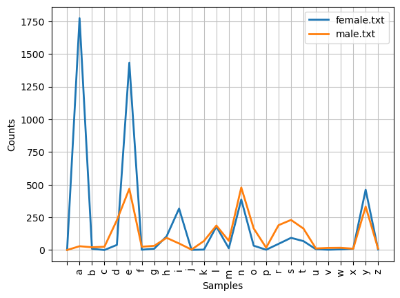

```python
cfd=nltk.ConditionalFreqDist((fileid,name[-1]) \
                             for fileid in names.fileids() \
                            for name in names.words(fileid))
cfd.plot()
```

## Pronouncing dictionary

NLTK has the CMU Pronouncing Dictionary for U.S. English. It was designed for speech synthesizers. For each word this lexicon provides a list of phonetic codes called **phones** which are distinct labels for each sound.

```python
entries=nltk.corpus.cmudict.entries()
print('Number of entries:',len(entries))
for entry in entries[41025:41045]:
    print(entry)
```

```
Number of entries: 133737
('favor', ['F', 'EY1', 'V', 'ER0'])
('favorability', ['F', 'AE2', 'V', 'ER0', 'AH0', 'B', 'IH1', 'L', 'IH0', 'T', 'IY0'])
('favorable', ['F', 'EY1', 'V', 'ER0', 'AH0', 'B', 'AH0', 'L'])
('favorable', ['F', 'EY1', 'V', 'R', 'AH0', 'B', 'AH0', 'L'])
('favorably', ['F', 'EY1', 'V', 'ER0', 'AH0', 'B', 'L', 'IY0'])
('favorably', ['F', 'EY1', 'V', 'R', 'AH0', 'B', 'L', 'IY0'])
('favored', ['F', 'EY1', 'V', 'ER0', 'D'])
('favoring', ['F', 'EY1', 'V', 'ER0', 'IH0', 'NG'])
('favorite', ['F', 'EY1', 'V', 'ER0', 'IH0', 'T'])
('favorite', ['F', 'EY1', 'V', 'R', 'AH0', 'T'])
('favorites', ['F', 'EY1', 'V', 'ER0', 'IH0', 'T', 'S'])
('favorites', ['F', 'EY1', 'V', 'R', 'AH0', 'T', 'S'])
('favoritism', ['F', 'EY1', 'V', 'ER0', 'IH0', 'T', 'IH2', 'Z', 'AH0', 'M'])
('favors', ['F', 'EY1', 'V', 'ER0', 'Z'])
('favre', ['F', 'EY1', 'V', 'ER0'])
('favreau', ['F', 'AH0', 'V', 'R', 'OW1'])
('favro', ['F', 'AE1', 'V', 'R', 'OW0'])
('faw', ['F', 'AO1'])
('fawbush', ['F', 'AO1', 'B', 'UH0', 'SH'])
('fawcett', ['F', 'AO1', 'S', 'IH0', 'T'])
```

Note that for some words there are alternative pronounciations, for example "favorable", "favorably", "favorite". The phone symbols are given in http://en.wikipedia.org/wiki/Arpabet. The phones contain digits to primary stress (1), secondary stress (2) and no stress(0).

Search for words rhyming with syllable sounding like *nicks*.

The code below uses the fact that every entry in *entries* has 2 parts, referred to in the code as *word* and *pron*.

```python
syllable=['N','IH0','K','S']
print([word for word, pron in entries if pron[-4:]==syllable])
```

```
["atlantic's", 'audiotronics', 'avionics', 'beatniks', 'calisthenics', 'centronics', 'chamonix', 'chetniks', "clinic's", 'clinics', 'conics', 'conics', 'cryogenics', 'cynics', 'diasonics', "dominic's", 'ebonics', 'electronics', "electronics'", "endotronics'", 'endotronics', 'enix', 'environics', 'et…
```

In the suggested rhymes above there are variations of spelling: *nics*, *niks*, *nix*, *ntic's* (*atlantic's*). Search for another difference between spelling and pronounciation typical for English.

```python
[w for w, pron in entries if pron[-1] == 'M' and w[-1] == 'n']
```

```
['autumn', 'column', 'condemn', 'damn', 'goddamn', 'hymn', 'solemn']
```

## WordNet

It is important to have a measure of distance between words based on the similarity of their meaning or semantic content as opposed to similarity of their syntactical representation (e.g. their string format or word count).

**WordNet** created in Cognitive Science Laboratory of Princeton University gives tools for measuring semantic similarity. **Wordnet** is a semantically oriented English dictionary, similar to thesaurus.

Nouns, verbs, adjectives and adverbs in this database are grouped into cognitive synonym sets (**synsets**).

The most frequently encoded relation among synsets is the **super-subordinate relation** (also called **hyperonymy**, **hyponymy** or **ISA relation**).

WordNet links more general synsets like *furniture, piece_of_furniture* to increasingly specific ones like *bed* and *bunkbed*.

See more detailed description on the [WordNet](https://wordnet.princeton.edu/) page or [here](https://arxiv.org/ftp/arxiv/papers/1310/1310.8059.pdf).

### Senses and synonyms

WordNet has advanced tools for analyzing multiple senses of words, their synonyms and similarity based on those.

Function *synset()* finds **synsets** or "synonym sets" for a word. These are also called **lemmas**.

```python
nltk.download('omw-1.4')
```

```
True
```

```python
from nltk.corpus import wordnet as wn
wn.synsets('motorcar')
```

```
[Synset('car.n.01')]
```

There was only one word found in synset for "motorcar" - its synonym "car". In turn, "car" may have lemmas of its own.

```python
print('Lemmas:',wn.synset('car.n.01').lemma_names())
print('Definition:',wn.synset('car.n.01').definition())
print('Example:',wn.synset('car.n.01').examples())
```

```
Lemmas: ['car', 'auto', 'automobile', 'machine', 'motorcar']
Definition: a motor vehicle with four wheels; usually propelled by an internal combustion engine
Example: ['he needs a car to get to work']
```

To eliminate ambiguity of word meanings synsets are usually paired with a word to form **lemma**.

```python
wn.synset('car.n.01').lemmas()
```

```
[Lemma('car.n.01.car'),
 Lemma('car.n.01.auto'),
 Lemma('car.n.01.automobile'),
 Lemma('car.n.01.machine'),
 Lemma('car.n.01.motorcar')]
```

```python
print(wn.lemma('car.n.01.automobile')) # look up for a lemma
print(wn.lemma('car.n.01.automobile').synset()) # get synset corresponding to lemma
print(wn.lemma('car.n.01.automobile').name()) # get name of lemma
```

```
Lemma('car.n.01.automobile')
Synset('car.n.01')
automobile
```

Some words may be ambiguous and have multiple synsets.

```python
print(wn.synsets('dog'))
```

```
[Synset('dog.n.01'), Synset('frump.n.01'), Synset('dog.n.03'), Synset('cad.n.01'), Synset('frank.n.02'), Synset('pawl.n.01'), Synset('andiron.n.01'), Synset('chase.v.01')]
```

```python
for synset in wn.synsets('dog'):
    print(synset.lemma_names())
```

```
['dog', 'domestic_dog', 'Canis_familiaris']
['frump', 'dog']
['dog']
['cad', 'bounder', 'blackguard', 'dog', 'hound', 'heel']
['frank', 'frankfurter', 'hotdog', 'hot_dog', 'dog', 'wiener', 'wienerwurst', 'weenie']
['pawl', 'detent', 'click', 'dog']
['andiron', 'firedog', 'dog', 'dog-iron']
['chase', 'chase_after', 'trail', 'tail', 'tag', 'give_chase', 'dog', 'go_after', 'track']
```

All lemmas of a word can be reached as:

```python
wn.lemmas('dog')
```

```
[Lemma('dog.n.01.dog'),
 Lemma('frump.n.01.dog'),
 Lemma('dog.n.03.dog'),
 Lemma('cad.n.01.dog'),
 Lemma('frank.n.02.dog'),
 Lemma('pawl.n.01.dog'),
 Lemma('andiron.n.01.dog'),
 Lemma('chase.v.01.dog')]
```

Write down all senses of word "dish". Show all synsets, all lemmas for this word and groups of synonyms.

```python
print('Lemmas: ',wn.lemmas('dish'))
print('Synsets: ',wn.synsets("dish"))
for synset in wn.synsets('dish'):
    print(synset.lemma_names())
```

```
Lemmas:  [Lemma('dish.n.01.dish'), Lemma('dish.n.02.dish'), Lemma('dish.n.03.dish'), Lemma('smasher.n.02.dish'), Lemma('dish.n.05.dish'), Lemma('cup_of_tea.n.01.dish'), Lemma('serve.v.06.dish'), Lemma('dish.v.02.dish')]
Synsets:  [Synset('dish.n.01'), Synset('dish.n.02'), Synset('dish.n.03'), Synset('smasher.n.02'), Synset('dish.n.05'), Synset('cup_of_tea.n.01'), Synset('serve.v.06'), Synset('dish.v.02')]
['dish']
['dish']
['dish', 'dishful']
['smasher', 'stunner', 'knockout', 'beauty', 'ravisher', 'sweetheart', 'peach', 'lulu', 'looker', 'mantrap', 'dish']
['dish', 'dish_aerial', 'dish_antenna', 'saucer']
['cup_of_tea', 'bag', 'dish']
['serve', 'serve_up', 'dish_out', 'dish_up', 'dish']
['dish']
```

A synset is identified with a 3-part name of the form: word.pos.nn.

Wordnet Has hierarchy of concepts where nodes correspond to synsets and edges show **hypernym**/**hyponym** relationships concepts. Hypernym means superordinate and hyponym means subordinate relationship.

```python
dog=wn.synset('dog.n.01')
types_of_dog=dog.hyponyms()
print(types_of_dog)
print('Dogs: ',sorted([lemma.name() for synset in types_of_dog for lemma in synset.lemmas()]))
```

```
[Synset('leonberg.n.01'), Synset('newfoundland.n.01'), Synset('pug.n.01'), Synset('corgi.n.01'), Synset('dalmatian.n.02'), Synset('cur.n.01'), Synset('lapdog.n.01'), Synset('pooch.n.01'), Synset('spitz.n.01'), Synset('basenji.n.01'), Synset('griffon.n.02'), Synset('poodle.n.01'), Synset('great_pyren…
Dogs:  ['Belgian_griffon', 'Brussels_griffon', 'Great_Pyrenees', 'Leonberg', 'Mexican_hairless', 'Newfoundland', 'Newfoundland_dog', 'Welsh_corgi', 'barker', 'basenji', 'bow-wow', 'carriage_dog', 'coach_dog', 'corgi', 'cur', 'dalmatian', 'doggie', 'doggy', 'griffon', 'hunting_dog', 'lapdog', 'mongre…
```

Look also at hypernyms and paths.

```python
print(dog.hypernyms())
paths=dog.hypernym_paths()
print(len(paths))
print('Path1: ',paths[0])
print('Path2: ',paths[1])
```

```
[Synset('domestic_animal.n.01'), Synset('canine.n.02')]
2
Path1:  [Synset('entity.n.01'), Synset('physical_entity.n.01'), Synset('object.n.01'), Synset('whole.n.02'), Synset('living_thing.n.01'), Synset('organism.n.01'), Synset('animal.n.01'), Synset('domestic_animal.n.01'), Synset('dog.n.01')]
Path2:  [Synset('entity.n.01'), Synset('physical_entity.n.01'), Synset('object.n.01'), Synset('whole.n.02'), Synset('living_thing.n.01'), Synset('organism.n.01'), Synset('animal.n.01'), Synset('chordate.n.01'), Synset('vertebrate.n.01'), Synset('mammal.n.01'), Synset('placental.n.01'), Synset('carni…
```

Observe roots.

```python
dog.root_hypernyms()
```

```
[Synset('entity.n.01')]
```

Hypernyms and hyponyms are **lexical relations**, they relate synsets. Other types of relations are **meronyms** and **holonyms**.

Parts of a tree are meronyms:

- trunk, leaf, etc, are *part_meronyms()*
- A substance a tree is made of, like heartwood or sapwood are *substance_meronyms()*

What is composed, formed with trees - forest - is a *member_holonyms()*

```python
print(wn.synset('tree.n.01').part_meronyms())
print(wn.synset('tree.n.01').substance_meronyms())
print(wn.synset('tree.n.01').member_holonyms())
```

```
[Synset('burl.n.02'), Synset('limb.n.02'), Synset('trunk.n.01'), Synset('stump.n.01'), Synset('crown.n.07')]
[Synset('sapwood.n.01'), Synset('heartwood.n.01')]
[Synset('forest.n.01')]
```

Relationships between verbs may be **entailments**:

```python
print('For "walk": ',wn.synset('walk.v.01').entailments())
print('For "eat": ',wn.synset('eat.v.01').entailments())
```

```
For "walk":  [Synset('step.v.01')]
For "eat":  [Synset('chew.v.01'), Synset('swallow.v.01')]
```

For opposite relationships there are **antonymy**:

```python
print('For "demand": ',wn.lemma('supply.n.02.supply').antonyms())
print('For "rush": ',wn.lemma('rush.v.01.rush').antonyms())
print('For "horizontal": ',wn.lemma('horizontal.a.01.horizontal').antonyms())
print('For "staccato": ',wn.lemma('staccato.r.01.staccato').antonyms())
```

```
For "demand":  [Lemma('demand.n.02.demand')]
For "rush":  [Lemma('linger.v.04.linger')]
For "horizontal":  [Lemma('vertical.a.01.vertical'), Lemma('inclined.a.02.inclined')]
For "staccato":  [Lemma('legato.r.01.legato')]
```

Function *synset1.path_similarity(synset2)* returns a score denoting how similar two word senses are, based on the shortest path that connects the senses in the is-a (hypernym/hyponym) taxonomy. The score is in the range 0 to 1. Large score means similar words.

```python
dog = wn.synset('dog.n.01')
pet = wn.synset('pet.n.01')
table = wn.synset('table.n.01')
print('Similarity of dog to pet = %s' % dog.path_similarity(pet))
print('Similarity of dog to table = %s' % dog.path_similarity(table))
print('Similarity of dog to horse = %s' % \
      wn.synsets('dog')[0].path_similarity(wn.synsets('horse')[0]))
```

```
Similarity of dog to pet = 0.25
Similarity of dog to table = 0.07142857142857142
Similarity of dog to horse = 0.125
```

Path Similarity is not the only mesure implemented in WordNet.

There are, for example, **Leacock-Chodorow Similarity**, **Wu-Palmer Similarity**, **Resnik Similarity**, **Jiang-Conrath Similarity**, **Lin Similarity** (see descriptions [here](https://arxiv.org/ftp/arxiv/papers/1310/1310.8059.pdf)).